# inlabru: an R package for Bayesian spatial modelling from ecological survey data - Bachl - 2019 - Methods in Ecology and Evolution - Wiley Online Library

[Methods in Ecology and Evolution](https://besjournals.onlinelibrary.wiley.com/journal/2041210x)

[Volume 10, Issue 6](https://besjournals.onlinelibrary.wiley.com/toc/2041210x/2019/10/6)

APPLICATION

Free Access

# inlabru: an R package for Bayesian spatial modelling from ecological survey data

[Fabian E. Bachl](https://besjournals.onlinelibrary.wiley.com/action/doSearch?ContribAuthorStored=Bachl%2C+Fabian+E)

[Finn Lindgren](https://besjournals.onlinelibrary.wiley.com/action/doSearch?ContribAuthorStored=Lindgren%2C+Finn)

[David L. Borchers](https://besjournals.onlinelibrary.wiley.com/action/doSearch?ContribAuthorStored=Borchers%2C+David+L)

[Janine B. Illian](https://besjournals.onlinelibrary.wiley.com/action/doSearch?ContribAuthorStored=Illian%2C+Janine+B)

First published: 24 February 2019

https://doi.org/10.1111/2041-210X.13168

Citations: 15

## Abstract

1. Spatial processes are central to many ecological processes, but fitting models that incorporate spatial correlation to data from ecological surveys is computationally challenging. This is particularly true of point pattern data (in which the primary data are the locations at which target species are found), but also true of gridded data, and of georeferenced samples from continuous spatial fields.
2. We describe here the R package inlabru that builds on the widely used RINLA package to provide easier access to Bayesian inference from spatial point process, spatial count, gridded, and georeferenced data, using integrated nested Laplace approximation (INLA, Rue et al., 2009).
3. The package provides methods for fitting spatial density surfaces and estimating abundance, as well as for plotting and prediction. It accommodates data that are points, counts, georeferenced samples, or distance sampling data.
4. This paper describes the main features of the package, illustrated by fitting models to the gorilla nest data contained in the package spatstat (Baddeley, & Turner, 2005), a line transect survey dataset contained in the package dsm (Miller, Rexstad, Burt, Bravington, & Hedley, 2018), and to a georeferenced sample from a simulated continuous spatial field.

## 1 INTRODUCTION

Many ecological datasets exhibit spatial correlation in observed variables, due to biotic or abiotic processes such as dispersal limitation, social aggregation, and spatial structure in unobserved explanatory variables. Whether the observations are points (e.g. animal locations), counts (e.g. the numbers of animals in spatial samples) or values of some continuous variable (e.g. nutrient levels at sampled points), spatial correlation causes every observation to depend on every other observation within some unknown correlation range. Dealing with this requires models that are mathematically more complex and computationally more demanding than is the case when there is independence among observations.

We account for spatial dependence by incorporating a Gaussian random field (GRF) into models. GRFs are spatially continuous random processes in which random variables at any point in space are normally distributed and are correlated with random variables at other points in space according to a continuous correlation process. GRFs provide a means of modelling the spatial signal in the observations that cannot be accounted for by covariates.

In the case of point data and count data, the GRF is linked to the response variable by a log link function, to give a log Gaussian Cox process (LGCP) model (Møller, & Waagepetersen, 2007). (Called ‘log Gaussian’ because the log of the intensity at any point is assumed to be normally distributed, and ‘Cox process’ because a Poisson process that has a randomly varying intensity function is called a Cox process.) What spatial statisticians call the ‘intensity’ is the density in our context, and we will use the term ‘density’ for this henceforth.

The GRF is approximated by the solution to a stochastic partial differential equation (SPDE; see Lindgren, Rue, & Lindström, 2011, for details). We do not have space to describe the details of SPDEs, but fortunately the mathematical details need not be understood to use them in inlabru. It is sufficient to know that SPDEs provide an efficient way of approximating the GRF in continuous space (Simpson, Illian, Lindgren, Sørbye, & Rue, 2016).

Integrated nested Laplace approximation (INLA) Bayesian methods (Rue, Martino, & Chopin, 2009) are used for inference. INLA is a fast and accurate alternative to Markov chain Monte Carlo (MCMC) for fitting latent Gaussian models, i.e., hierarchical models in which there are unobserved (latent) normally distributed random variables. The models we consider here, in which the GRF is latent, are of this type. We refer the reader to the ‘Gentle INLA tutorial’ at https://www.precisionanalytics.ca/blog-1/inla for more about INLA, and to the R‐INLA project at http://www.rinla.org/ for more about the RINLA package on which the inlabru package builds.

The RINLA package currently requires users to have knowledge of likelihood approximation schemes, and does not allow inference when detection probability is unknown, as is common in many wildlife surveys. The inlabru package makes fitting spatial models with INLA more accessible to non‐specialist users by employing simpler syntax, and it extends the class of models that can be fitted to include distance sampling.

We illustrate the scope of the package by fitting models to point and count data from a survey of gorilla (Gorilla gorilla) nests by Funwi‐Gabga (2008), a line transect survey of pantropical spotted dolphins (Stenella attenuata) ((see http://seamap.env.duke.edu/dataset/25) for details of this survey), and a simulated survey of a continuous spatial field. Other examples can be found at http://inlabru.org/tutorials.

## 2 DATA FORMAT AND VISUALIZATION

The inlabru package supports the sp package data structures (Pebesma, & Bivand, 2005). These are well documented within sp, together with powerful functions for manipulating them. The SpatialPointsDataFrame structure stores spatial points together with spatial covariate data and attributes of points (e.g. size or species). SpatialLinesDataFrames store spatial data for line transect surveys and SpatialPolygonsDataFrames are used to define survey regions and sample plots.

Continuous space is approximated in inlabru using a “mesh” (a tiling of space with triangular tiles – see Figure 1 for example). We use the inla.mesh class of object from the INLA package for this approximation.

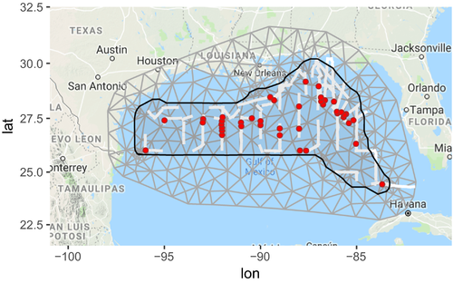

**Figure 1**

Pantropical dolphin survey data plotted using ggmap and the gm method. Grey triangles show the inla.mesh object. The survey region boundary (black) is held in a SpatialPolygonsDataFrame. The line transects (white lines) are held in a SpatialLinesDataFrame and the detected dolphins (red points) are held in a SpatialPointsDataFrame

Data visualization tools in inlabru are built on the ggplot2 (Wickham, 2009) and ggmap (Kahle & Wickham, 2013) packages, with customized inlabru functions such as gg and gm to extend their functionality. Figure 1 shows an example of such a plot generated from a line transect survey of pantropical spotted dolphins in the Gulf of Mexico.

## 3 KEY SYNTAX

Models are defined by specifying

1. a formula for the linear or nonlinear predictor that defines the log density function,
2. the components of this predictor (one of which is typically an SPDE), and
3. the observed variable distribution.

Models are fitted using the function bru() or, for LGCP models, lgcp(). Examples are given below.

## 4 SPATIAL COUNT DATA

We begin by using inlabru to infer a smooth spatial density surface from plot samples in which the response is the count of gorilla nests in each plot (see Figure 2 (a)). Although the exact locations of all nests were recorded, we initially use only nest counts in a sample of plots. The R code showing how to load the package and the data is provided as Supporting Information S1.

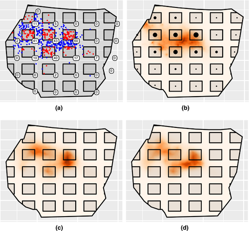

**Figure 2**

Analysis of gorilla nests as a count and as a point process model. Panel (a) depicts the survey region, search plots, undetected (blue) and detected (red) nests, and the nest counts (white boxes). Panel (b) shows a density fit with bru to nest counts, associating counts with the plot centres. Panels (c) and (d) show point process fits obtained with lgcp using only nests within the plots, and using all nests, respectively

## 5 FITTING POINT PROCESSES

We now consider the case in which the data are the *locations* of nests within plots. Some information about the spatial process governing nest locations is lost when locations are aggregated into counts within plots, and we would like to use all the information in the data. In this case, the response variables are the coordinates of the individual nests, and these locations are random variables, whereas with count data the locations of the plots were fixed and known and the counts were random variables. Spatial point processes models (Møller, & Waagepetersen, 2007; Illian, Penttinen, Stoyan, & Stoyan, 2008; Baddeley, Rubak & Turner, 2015) are used when the points themselves are the random variables. More specifically, we use an LGCP, in which the log density includes a GRF, to model overdispersion and clustering that cannot be accounted for by covariates.

### 5.2 Inference for univariate point processes: distance sampling detection function

We illustrate inlabru’s ability to model one‐dimensional point processes by fitting a detection function to the perpendicular distances of detected dolphins on the line transect survey shown in Figure 1. The R code showing how to load and prepare the data is provided as Supporting Information S2.

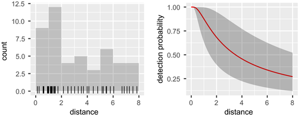

**Figure 3**

Pantropical dolphin detection distances (left) and fitted hazard rate detection function (right), showing 95% credibile region. With adequate fit, the red line is a smooth through the histogram, as is apparent here

### 5.3 Inference for thinned Poisson processes: distance sampling

An analysis of these data (also assuming uniform group distribution within searched strips) using the R package dsm is available at http://distancesampling.org/R/vignettes/mexico-anaysis.html. The methods implemented in inlabru and dsm differ in a number of ways, including that inlabru implements a fully‐Bayesian approach, so one can specify priors on parameters (not illustrated here), and inlabru estimates detection probability and the density surface simultaneously, while dsm estimates detection probability in one step and the density surface conditional on this estimate, in another.

The key to simultaneous estimation of detection probability and the density surface is the fact that if the locations of points arise from a Poisson process, then the locations of the *detected* points arise from a *thinned* Poisson process. “Thinning” involves detecting points with some probability (*h*, say) that is less than 1. The density (intensity) of a thinned Poisson process is the unthinned density *D*, multiplied by the thinning probability *h*. For example, if *h* = 0.5 so that half the points are detected on average, then the density of detected points is half that of the all points: *Dh* = *D*/2. On a line transect survey, the probability of missing σ point depends on its distance *d* from the line, so that *h* is a function of distance (*h*(*d*)) and the density of the thinned Poisson process at the point’s location is *Dh*(*d*), where *D* is the underlying density at this location. Writing *D* as *D* = exp (Intercept) and noting that *Dh*(*d*) = exp (Intercept+ log (*h*(*d*)), we see that the log density of the thinned Poisson process is equal to the log density of the underlying process plus the log of the detection probability. This is convenient, because it means that we can do inference for thinned LGCPs by simply adding a term for the thinning probability to the log density.

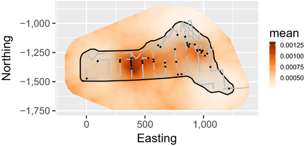

**Figure 4**

Predicted density surface (in counts per square km) of a point process model for dolphin groups fitted jointly with a hazard rate detection function (not shown)

We can add further processes, such as a group size probability model. This allows us to make detection probability depend on group size and to model a spatially varying group size distribution. We do not illustrate this here for lack of space.

## 6 GEOREFERENCED DATA FROM A CONTINUOUS SPATIAL FIELD

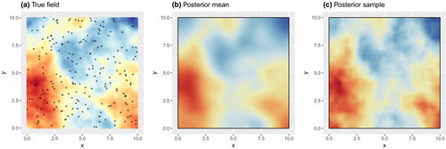

**Figure 5**

(a) A simulated continuous spatial field, showing sample locations, (b) the posterior mean of the model fitted to the sample data, and (c) a sample from the posterior distribution of the field

The mean of the fitted model is shown in Figure 5(b), while a sample from the posterior distribution of the field is shown in Figure 5(c). Note that the mean surface is necessarily smoother than the true field (which is conceptually a draw from a random field with the given mean), while the posterior sample better reflects the fine‐scale structure of the true field.

## 7 DISCUSSION

The inlabru package makes Bayesian spatial modelling with INLA, including point process modelling, more accessible to ecologists. It allows one to model species distribution and estimate density and abundance with data that are (a) complete spatial maps of the locations of individuals or groups, (b) counts in plots, (c) points, and (d) distance sampling data.

It also provides a means of doing Bayesian spatial modelling with distance sampling data. Its distance sampling capabilities are not as well developed as those of the frequentist package dsm (Miller et al., 2018), and unlike dsm, it estimates the detection probability and density surface simultaneously. It shares this feature with the frequentist package unmarked (Fiske, & Chandler, 2011), although unmarked has no spatial modelling capabilities. Simultaneous estimation of detection probability and the density surface is conceptually satisfying, but the jury is out on whether this, or estimation of the two in separate steps, is preferable in practice

Features of inlabru that we do not have space to describe include its ability to do temporal and spatio‐temporal modelling and its ability to simultaneously estimate the density of a point process and the spatially varying density of what spatial statisticians call “marks” on points (dolphin group size, being an example) as well as its impact on the shape of the detection function.

Features under development include point transect data, modelling multi‐species density when there is spatial interaction or common explanatory environmental data for the distribution of different species sharing a habitat, and modelling of habitat preference based on telemetry data. There are some technical obstacles to implementing spatial capture‐recapture methods (Efford, 2004; Borchers, & Efford, 2008; Royle, & Young, 2008) in inlabru, but work in this area is ongoing.

## ACKNOWLEDGEMENTS

This research was funded by EPSRC grants EP/K041061/1, EP/K041053/1 and EP/K041053/2.

## DATA ACCESSIBILITY

All data used in this paper are available in the R package inlabru, which can be downloaded from the Comprehensive R Archive Network at [https://CRAN.R-project.org/package=inlabru](https://cran.r-project.org/package=inlabru).

## AUTHORS’ CONTRIBUTIONS

F.B., D.B., J.I. and F.L. conceived the ideas and designed methodology; F.B. and DB analysed the data; F.B. and F.L. wrote the code, with a minor contribution from D.B.; F.B. led the writing of the manuscript, with major contributions from all authors.